# Desmatamento em Áreas Protegidas da Amazônia

Letícia Lopes

## Contexto

O desmatamento da floresta amazônica se destaca nas discussões sobre mudanças climáticas uma vez que é responsável por quase metade das emissões de gases de efeito estufa pelo Brasil [^1].

As áreas protegidas formam uma barreira contra esse desmatamento, sendo que diversos projetos de conservação visam apoiar essas áreas no cumprimento de seus objetivos. O [**Projeto LIRA - Legado Integrado da Região Amazônica**](https://lira.ipe.org.br/) se soma às iniciativas existentes e abrange 43 unidades de conservação e 43 terras indígenas da Amazônia brasileira.

Para analisar o desmatamento na Amazônia e nas áreas apoiadas pelo LIRA, foram utilizados dados gerados pelo **INPE - Instituto Nacional de Pesquisas Espaciais** e disponibilizados no portal [**TerraBrasilis**](http://terrabrasilis.dpi.inpe.br/).

## Desmatamento

### Visão geral

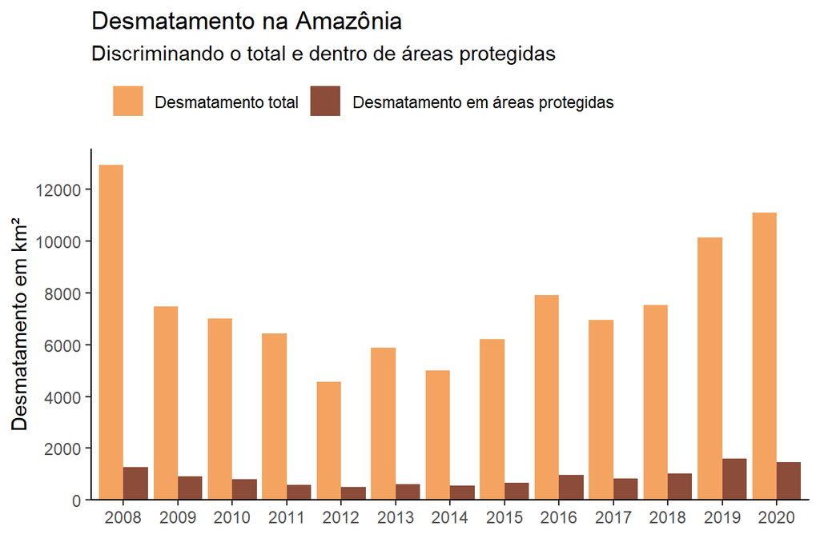

### Áreas apoiadas pelo LIRA

As áreas apoiadas pelo LIRA correspondem a 34% do território das áreas protegidas da Amazônia e contam com apoio há longo prazo da [**Fundação Gordon e Betty Moore**](https://www.moore.org/initiative-strategy-detail?initiativeId=andes-amazon-initiative). Isso pode explicar o fato dessas áreas sofrerem menor impacto de perda de vegetação, como vemos abaixo.

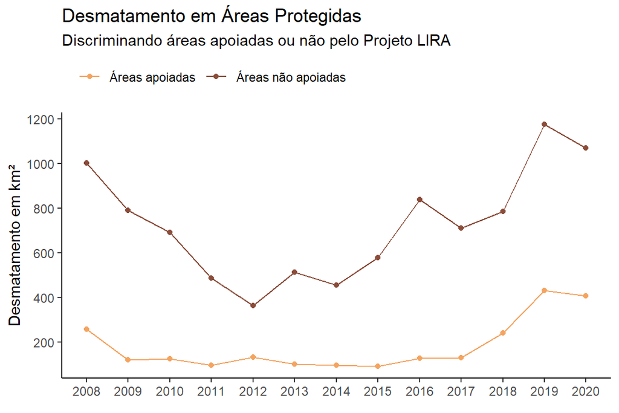

Apesar da ameaça do desmatamento ser menor nesses locais, vale destacar que o impacto tem aumentado nos últimos dois anos tanto nesses territórios quanto no bioma como um todo. Por isso, uma atenção especial da gestão do Projeto pode ser direcionada segundo a intensidade de desmatamento, ordenado na tabela abaixo.

|  | Área Protegida | Desmatamento (km²) |
| --- | --- | --- |
| 1 | TI Cachoeira Seca | 72.44 |
| 2 | TI Apyterewa | 63.27 |
| 3 | FLONA Altamira | 58.53 |
| 4 | RESEX Chico Mendes | 57.41 |
| 5 | REBIO Nascentes Serra Do Cachimbo | 26 |
| 6 | TI Trincheira Bacaja | 23.54 |
| 7 | FLOTA De Iriri | 18.18 |
| 8 | TI Kayapó | 16.47 |
| 9 | ESEC Da Terra Do Meio | 15.36 |
| 10 | PAREST De Guajará-Mirim | 7.28 |

[output cut: 39 more lines]

Quanto à intensidade do desmatamento, se percebe na tabela acima a grande variação que existe entre as áreas, sendo que nas dez áreas mais ameaçadas esse valor varia entre 7 e 72 km². Além disso, na maior parte das áreas afetadas, o desmatamento está abaixo de 2 km².

Por isso, é possível identificar que existem diferentes perfis de áreas cobertas pelo LIRA (veja mapa abaixo):

- Aquelas onde não ocorre desmatamento (em cinza);
- Áreas pouco afetadas (entre 1 e 10 km² de desmatamento);
- Áreas com nível moderado de impacto (entre 10 e 50 km²);
- Áreas com impacto acentuado (maior do que 50 km²).

Para cada um desses locais, ações de gestão específicas podem ser direcionados pela equipe do Projeto.

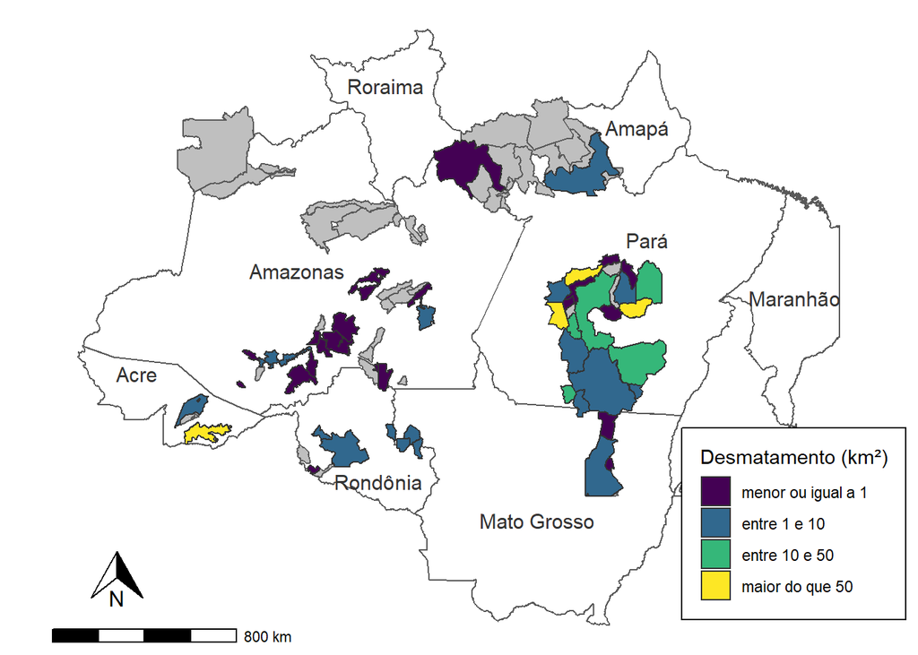

## Considerações Finais

Entendendo o contexto de ameaça e o nível de impacto que atinge as áreas protegidas, é possível estabelecer ações prioritárias de monitoramento e proteção, garantindo que o apoio fornecido atenda às necessidades mais urgentes daquela área. Vale dizer ainda que o desmatamento é um dentre outros fatores que ameaçam a conservação do bioma amazônico, logo é essencial uma análise integrada para melhor tomada de decisão.

[^1]: Saiba mais sobre as emissões de gases de efeito estufa no Brasil em https://seeg.eco.br.